# レポート課題 第7回

氏名：木澤 祐人  
学籍番号：2094572t

# 準備

## Google Driveのマウントと作業フォルダへの移動

```python
from google.colab import drive
drive.mount('/content/drive')
%cd /content/drive/'My Drive'/情報管理/07/
```

```
/content/drive/My Drive/情報管理/07
```

## 必要ライブラリのインポート

```python
import wave as wave
import numpy as np
import matplotlib.pyplot as plt
```

# NLMSアルゴリズムによるエコーキャンセリング

## マイク収録信号 及び スピーカ再生音データの読み込み

まず、マイク収録信号を読み込む。  
今回対象となるファイルは `echo_mixed_input_2.wav` である。

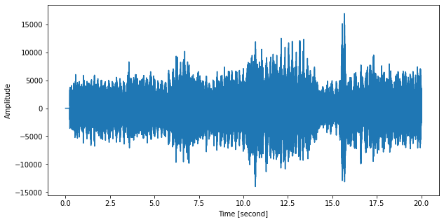

```python
wav_file = 'echo_mixed_input_2.wav'
with wave.open(wav_file, 'rb') as wav:
  sampling_frequency = wav.getframerate()
  wav_params = wav.getparams()
  input_data = wav.readframes(wav.getnframes())
  input_data = np.frombuffer(input_data, dtype=np.int16).astype(np.float32)

plt.figure(figsize=(10,5))
x = np.arange(np.size(input_data)) / sampling_frequency
plt.plot(x, input_data)
plt.xlabel('Time [second]')
plt.ylabel('Amplitude')
plt.show()
```

次に、参照信号であるスピーカ再生音データを読み込む。

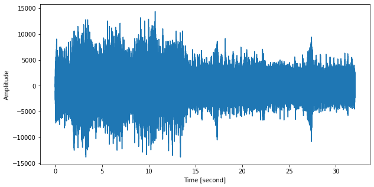

```python
ref_file = 'reference.wav'
with wave.open(ref_file, 'rb') as ref:
  reference_data = ref.readframes(ref.getnframes())
  reference_data = np.frombuffer(reference_data, dtype=np.int16).astype(np.float32)

plt.figure(figsize=(10,5))
x = np.arange(np.size(reference_data)) / sampling_frequency
plt.plot(x, reference_data)
plt.xlabel('Time [second]')
plt.ylabel('Amplitude')
plt.show()
```

## エコーキャンセリング

NLMSアルゴリズムの式を以下にまとめて示す。  
$y[n] = \sum_{k=0}^{K-1}\hat{h}_{\rm old}[k]x[n-k]$  
$e[n] = z[n] - y[n]$  
$\hat{h}_{\rm new} = \hat{h}_{\rm old} + \frac{\mu}{\sum_{k=0}^{K-1}(x[n-k])^{2}+\epsilon}e[n]x[n-k]$

$n$，$k$は時刻を表す記号  
$x[n]$はスピーカから再生する信号（参照信号，`reference_data`）  
$\hat{h}_{\rm old}[k]$，$\hat{h}_{\rm new}[k]$は推定したインパルス応答（`estimated_rir`，長さ $K$）。oldは更新前，newは更新後。  
$y[n]$は推定したマイク入力音（`estimated_echo`）  
$z[n]$は実際のマイク入力音（`input_data`）  
$e[n]$はエコーキャンセリングによる消し残り（`error`，`output_data`）  
$\mu$はNLMSアルゴリズムにおける学習率（`myu`）  
$\epsilon$はゼロ割を防ぐための小さい値（1e-10）

また、各種ハイパーパラメータを以下のように設定する。

```python
K = 1024

myu = 1.0

stop_update_time = 10.0

eps = 1e-10
```

以上の設定を用いて、NLMSアルゴリズムを次のように実装する。

```python
# マイク収録音(input_data)の長さ
N = np.size(input_data)
# 推定されたインパルス応答
estimated_rir = np.zeros(K)
# エコーキャンセリング後の信号
output_data = np.zeros(N)

for n in range(N):
  if n-K+1 < 0:
    # n-K+1<0の場合，以降の処理においてベクトルの
    # インデクスが負になるため，この場合は畳み込みをしない。
    output_data[n] = input_data[n]
  else:
    #
    # NLMSアルゴリズムによるエコーキャンセリングを実行する。
    #

    # 現在の推定インパルス応答と参照信号の畳み込みを行い，
    # スピーカの収録信号（エコー）を推定する。
    # 畳み込みについては07_02_convolve_rir.ipynbを参照
    reference_part = reference_data[n-K+1:n+1]
    reference_rev = np.flip(reference_part)
    estimated_echo = np.dot(estimated_rir, reference_rev)

    # 入力信号からエコー信号を引くことで、エコーを除去する。
    # このとき、減算結果がエコーの消し残り(error)である。
    output_data[n] = input_data[n] - estimated_echo
    error = output_data[n]

    # 正規化項(参照信号のパワー)を求める。
    norm = np.sum(reference_rev**2) + eps

    # インパルス応答の更新を止める時間(stop_update_time * sampling_rate)に
    # 達していない場合はインパルス応答の推定値を更新する
    if n < stop_update_time * sampling_frequency:
      estimated_rir += (myu / norm) * error * reference_rev
```

実行結果は次の通りである。

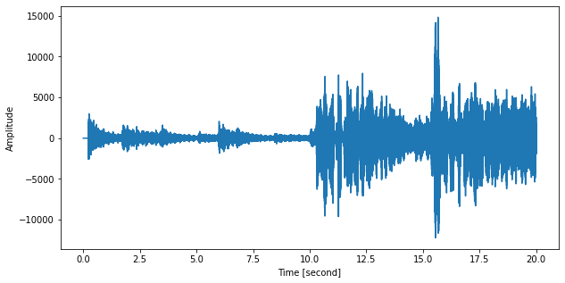

[interactive chart not shown]

```python
out_file = 'output.wav'
with wave.open(out_file, 'wb') as out:
  # 音声データの情報（wav_params）をセット
  out.setparams(wav_params)
  # numpy array型(32bit float)のデータをバイナリデータ（16bit short）に変換
  out_binary_data = output_data.astype(np.int16).tobytes()
  # データを書き込む
  out.writeframes(out_binary_data)

# データをプロット
plt.figure(figsize=(10,5))
x = np.arange(np.size(output_data)) / sampling_frequency # 横軸データ
plt.plot(x, output_data)
plt.xlabel('Time [second]')
plt.ylabel('Amplitude')
plt.show()

import IPython.display
IPython.display.display(IPython.display.Audio('output.wav'))
```

# 考察

得られた音声では、インパルス応答学習が終了した後に音声が開始されるが、同時にスピーカ音が大きくなってしまったために十分な雑音除去ができておらず、音声は依然聞き取りずらいままとなっている。  
これは今回使用したアルゴリズムがインパルス応答が時間により変化しないことを前提としており、学習終了後に起こるインパルス応答の変化が、そのまま消し残り $e[n]$ の増大につながり、結果としてエコーが残ってしまうのである。

問題は、目標とする音声が鳴っている間は学習ができない点である。  
したがって、ある時刻に目標の音声が鳴っているかどうかがわかれば、その都度学習を再開し、インパルス応答の変化に適応し続けることができると考えられる。  
今回のデータでは `0:13` から `0:15` 、`0:18` から `0:20` の時間で音声が一時的に途切れていることがわかる。  
そこで、先ほど使用したアルゴリズムを、上記の時間でも学習を行えるよう変更したものと、その実行結果を以下に示した。

```python
# マイク収録音(input_data)の長さ
N = np.size(input_data)
# 推定されたインパルス応答
estimated_rir = np.zeros(K)
# エコーキャンセリング後の信号
output_data = np.zeros(N)

for n in range(N):
  if n-K+1 < 0:
    # n-K+1<0の場合，以降の処理においてベクトルの
    # インデクスが負になるため，この場合は畳み込みをしない。
    output_data[n] = input_data[n]
  else:
    #
    # NLMSアルゴリズムによるエコーキャンセリングを実行する。
    #

    # 現在の推定インパルス応答と参照信号の畳み込みを行い，
    # スピーカの収録信号（エコー）を推定する。
    # 畳み込みについては07_02_convolve_rir.ipynbを参照
    reference_part = reference_data[n-K+1:n+1]
    reference_rev = np.flip(reference_part)
    estimated_echo = np.dot(estimated_rir, reference_rev)

    # 入力信号からエコー信号を引くことで、エコーを除去する。
    # このとき、減算結果がエコーの消し残り(error)である。
    output_data[n] = input_data[n] - estimated_echo
    error = output_data[n]

    # 正規化項(参照信号のパワー)を求める。
    norm = np.sum(reference_rev**2) + eps

    # インパルス応答の更新を止める時間(stop_update_time * sampling_rate)に
    # 達していない場合はインパルス応答の推定値を更新する
    if (n < stop_update_time * sampling_frequency) or (n > 13.0 * sampling_frequency and n < 15.0 * sampling_frequency) or (n > 18.0 * sampling_frequency and n < 20.0 * sampling_frequency):
      estimated_rir += (myu / norm) * error * reference_rev
```

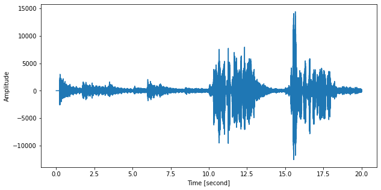

[interactive chart not shown]

```python
out_file = 'output.wav'
with wave.open(out_file, 'wb') as out:
  # 音声データの情報（wav_params）をセット
  out.setparams(wav_params)
  # numpy array型(32bit float)のデータをバイナリデータ（16bit short）に変換
  out_binary_data = output_data.astype(np.int16).tobytes()
  # データを書き込む
  out.writeframes(out_binary_data)

# データをプロット
plt.figure(figsize=(10,5))
x = np.arange(np.size(output_data)) / sampling_frequency # 横軸データ
plt.plot(x, output_data)
plt.xlabel('Time [second]')
plt.ylabel('Amplitude')
plt.show()

import IPython.display
IPython.display.display(IPython.display.Audio('output.wav'))
```

このように、目標の音声が流れていない時間を利用してその都度学習を再開し、断続的に学習を行うことで、変化し続けるインパルス応答にも対応できると考えられる。